# Quantitative Analysis | Assignment #1 & 2

Livesey Pack and Mehvish Jamal

10/26/2021

# Research Question

How does a mix of incomes in a geography contribute to a community’s economic prosperity?

# Prior Literature

According to the Social Science Research Council’s (2007) Mixed-Income Research Design Group, mixed-income communities facilitate the co-location of lower-income residents, who historically live in geographies of concentrated poverty in the United States, and higher-income neighbors. The proximity of these populations from diverse backgrounds enables greater social exchange that could contribute to greater opportunity for lower-income residents. They state that mixed-income strategies “[create] a stable, high-quality community that is home to residents of very diverse backgrounds.” Levy, McDade and Dumlao (2010) support this conclusion in their assessment of the benefits of mixed-income housing. They summarize the primary benefits of mixed-income housing strategies as: poverty alleviation, desegregation and urban revitalization.

# Population

- Total households (U.S. Census Bureau, 2010)
- Gini Index of Income Inequality (IPUMS National Historical Geographic Information System)
- Median home value (IPUMS National Historical Geographic Information System)
- Home-ownership rates (U.S. Census Bureau, 2010)
- Percent of population that is rent burdened (U.S. Census Bureau, 2010)

## Load Data

```r
#install.packages("survey")
#install.packages("srvyr")
#install.packages("tigris")
#install.packages("gridExtra")
#install.packages("dplyr")
```

We will be using the following libraries for this assignment:

```r
library(tidycensus)
library(tidyverse)
library(readxl)
library(knitr)
library(sf)
library(tigris)
library(gridExtra)
library(ipumsr)
library(survey)
library(srvyr)
library(dplyr)

# Change me
path <- "C:/Users/mehvi/Documents/MUP/Fall 2021/Quant Analysis/Assingment 1"
```

First, we will load a series of variables from the 2010 Census. This data is courtesy of the U.S. Census Bureau.

```r
CensusData_raw    <- read_csv("Social Explorer_Census Data_MSA Level2.csv")
# First row contains additional variable names / this command deletes the first row
CensusData      <- CensusData_raw[-1,]

# Keep variables
varkeep       <- c("tot-occhu", "tot_ownocu", "tot_rentocu", "rentburd1", "rentburd2", "rentburd3", "rentburd4", "rentburd5", "FIPS", "GEOID", "geo_CBSA")
CensusData    <- subset(CensusData, select = varkeep)
```

We used our collated census data to calculate a new variable, the percent of rent-burdened populations across several income strata. First, we had to tell R to read these variables as numbers, rather than text.

```r
CensusData <- CensusData %>%
  mutate(rentburd1 = as.numeric(as.factor(rentburd1)),
         rentburd2 = as.numeric(as.factor(rentburd2)),
         rentburd3 = as.numeric(as.factor(rentburd3)),
         rentburd4 = as.numeric(as.factor(rentburd4)),
         rentburd5 = as.numeric(as.factor(rentburd5)),
         tot_ownocu = as.numeric(as.factor(tot_ownocu)),
         `tot-occhu` = as.numeric(as.factor(`tot-occhu`)),
         tot_rentocu = as.numeric(as.factor(tot_rentocu)))
```

We then calculated this new variable and added it to our existing census data table.

```r
CensusData <- mutate(CensusData, tot_rentburd = `rentburd1` + `rentburd2` + `rentburd3` + `rentburd4` + `rentburd5`)
```

Then we calculated rates of homeownership.

```r
CensusData <- mutate(CensusData, pct_own = `tot_ownocu` / `tot-occhu`)
```

```r
CensusData <- mutate(CensusData, pct_rentburd = `tot_rentburd` / `tot_rentocu`)
```

Our final set of variables, median home value and income inequality are IPUMS data, courtesy of the 2019 American Community Survey and the National Historical Geographic Information System.

```r
IPUMS_housevalue <- read_csv("nghis0001_ds244_clean.csv")
IPUMS_inequality <- read_csv("nhgis0001_clean.csv")
```

Before we joined our data into one table, we cleaned up the joining variable name, “geo_CBSA,” to ensure we had a common variable across the data sets.

```r
CensusData <- CensusData %>% mutate(geo_CBSA = as.character(geo_CBSA))

IPUMS_housevalue <- IPUMS_housevalue %>% mutate(geo_CBSA = as.character(geo_CBSA))

IPUMS_inequality <- IPUMS_inequality %>% mutate(geo_CBSA = as.character(geo_CBSA))
```

We renamed variables for simplicity

```r
#rename(tablename, newvariable = old variable)
IPUMS_housevalue <- rename(IPUMS_housevalue, `med_houseval` = `MEDIAN HOUSE VALUE`)
```

```r
IPUMS_inequality <- rename(IPUMS_inequality, `inc_inequal` = `INCOME INEQUALITY`)
```

```r
IPUMS_housevalue <- rename(IPUMS_housevalue, `houseval_moe` = `Margin of Error`)
IPUMS_inequality <- rename(IPUMS_inequality, `incineq_moe` = `Margin of Error`)
```

and kept only relevant variables

```r
# Keep variables
varkeep       <- c("geo_CBSA", "GISJOIN", "CBSA", "GEOID", "med_houseval", "houseval_moe")
IPUMS_housevalue   <- subset(IPUMS_housevalue, select = varkeep)
```

```r
varkeep       <- c("geo_CBSA", "GISJOIN", "CBSA_Name", "GEOID", "inc_inequal", "incineq_moe")
IPUMS_inequality  <- subset(IPUMS_inequality, select = varkeep)
```

```r
IPUMS_inequality <- rename(IPUMS_inequality, `CBSA` = `CBSA_Name`)
```

Once the data was prepped, we joined data into one table, and then filtered to the data for CBSAs in Texas. The final table, including 72 observations, is highlighted below.

```r
data <- left_join(CensusData, IPUMS_housevalue, by = "geo_CBSA") %>%
  left_join(IPUMS_inequality, by = "geo_CBSA")

data1 <- filter(data, GEOID.y !=  'NA')

kable(head(data1))
```

| tot-occhu | tot_ownocu | tot_rentocu | rentburd1 | rentburd2 | rentburd3 | rentburd4 | rentburd5 | FIPS | GEOID.x | geo_CBSA | tot_rentburd | pct_own | pct_rentburd | GISJOIN.x | CBSA.x | GEOID.y | med_houseval | houseval_moe | GISJOIN.y | CBSA.y | GEOID | inc_inequal | incineq_moe |
| --- | --- | --- | --- | --- | --- | --- | --- | --- | --- | --- | --- | --- | --- | --- | --- | --- | --- | --- | --- | --- | --- | --- | --- |
| 409 | 209 | 843 | 291 | 894 | 573 | 38 | 1 | 545500 | 32000US0545500 | 45500 | 1797 | 0.5110024 | 2.131673 | G45500 | Texarkana, TX-AR Metro Area | 31000US45500 | 111500 | 3690 | G45500 | Texarkana, TX-AR Metro Area | 31000US45500 | 0.4875 | 0.0160 |
| 809 | 599 | 286 | 581 | 450 | 170 | 311 | 117 | 4810180 | 32000US4810180 | 10180 | 1629 | 0.7404203 | 5.695804 | G10180 | Abilene, TX Metro Area | 31000US10180 | 116100 | 2841 | G10180 | Abilene, TX Metro Area | 31000US10180 | 0.4524 | 0.0106 |
| 256 | 82 | 658 | 71 | 680 | 656 | 1 | 1 | 4810860 | 32000US4810860 | 10860 | 1409 | 0.3203125 | 2.141337 | G10860 | Alice, TX Micro Area; Corpus Christi-Kingsville-Alice, TX CSA | 31000US10860 | 71600 | 5417 | G10860 | Alice, TX Micro Area; Corpus Christi-Kingsville-Alice, TX CSA | 31000US10860 | 0.4854 | 0.0286 |
| 995 | 786 | 460 | 793 | 675 | 141 | 296 | 244 | 4811100 | 32000US4811100 | 11100 | 2149 | 0.7899497 | 4.671739 | G11100 | Amarillo, TX Metro Area | 31000US11100 | 140500 | 2458 | G11100 | Amarillo, TX Metro Area | 31000US11100 | 0.4569 | 0.0073 |
| 777 | 619 | 122 | 262 | 257 | 509 | 168 | 253 | 4811380 | 32000US4811380 | 11380 | 1449 | 0.7966538 | 11.877049 | G11380 | Andrews, TX Micro Area | 31000US11380 | 143900 | 19680 | G11380 | Andrews, TX Micro Area | 31000US11380 | 0.4237 | 0.0319 |
| 555 | 413 | 862 | 292 | 844 | 283 | 299 | 1 | 4811980 | 32000US4811980 | 11980 | 1719 | 0.7441441 | 1.994199 | G11980 | Athens, TX Micro Area | 31000US11980 | 108500 | 4336 | G11980 | Athens, TX Micro Area | 31000US11980 | 0.4702 | 0.0156 |

Drop repetitive columns

```r
data1 <- select(data1, -c(CBSA.y, GISJOIN.y, GEOID.y))
```

# Continuous Variables

```r
pown_t_test <- t.test(data$pct_own)
prentburd_t_test <- t.test(data$pct_rentburd)
houseval_t_test <- t.test(data$med_houseval)
```

```r
pown_quartiles <- quantile(data$pct_own, na.rm = TRUE)
prentburd_quartiles <- quantile(data$pct_rentburd, na.rm = TRUE)
houseval_quartiles <- quantile(data$med_houseval, na.rm = TRUE)
```

```r
pown_st_dev <- sd(data$pct_own, na.rm = TRUE)
prentburd_st_dev <- sd(data$pct_rentburd, na.rm = TRUE)
houseval_st_dev <- sd(data$med_houseval, na.rm = TRUE)
```

# Plot Histogram

```r
pown_hist <- ggplot(data) +
  geom_histogram(aes(x = pct_own),
                 bins = 30) +
  scale_x_continuous(trans = "log")
```

```r
prentburd_hist <- ggplot(data) +
  geom_histogram(aes(x = pct_rentburd),
                 bins = 30) +
  scale_x_continuous(trans = "log")
```

```r
#houseval_hist <- ggplot(data) +
  #geom_histogram(aes(x = med_houseval,
                 #bins = 30)
```

#Displaying Results

```r
cont_summary <- tibble(
  Variable = c("Homeownership Rate (percent)",
               "Rent Burdened Population (percent, 30% of income on rent or more)",
               "Median Home Value (dollars)"),
  `Sample mean` = c(pown_t_test$estimate,
                    prentburd_t_test$estimate,
                    houseval_t_test$estimate),
  `Population mean (95% confidence) - low` =
    c(pown_t_test$conf.int[1],
      prentburd_t_test$conf.int[1],
      houseval_t_test$conf.int[1]),
  `Population mean (95% confidence) - high` =
    c(pown_t_test$conf.int[2],
      prentburd_t_test$conf.int[2],
      houseval_t_test$conf.int[2]),
  Median = c(pown_quartiles[3],
             prentburd_quartiles[3],
             houseval_quartiles[3]),
  `Interquartile range` = c(pown_quartiles[4] - pown_quartiles[2],
                            prentburd_quartiles[4] - prentburd_quartiles[2],
                            (houseval_quartiles[4] - houseval_quartiles[2])),
  `Standard deviation` = c(pown_st_dev,
                          prentburd_st_dev,
                          houseval_st_dev))

kable(cont_summary, digits = 0)
```

| Variable | Sample mean | Population mean (95% confidence) - low | Population mean (95% confidence) - high | Median | Interquartile range | Standard deviation |
| --- | --- | --- | --- | --- | --- | --- |
| Homeownership Rate (percent) | 5 | 3 | 7 | 1 | 0 | 33 |
| Rent Burdened Population (percent, 30% of income on rent or more) | 10 | 7 | 13 | 4 | 4 | 52 |
| Median Home Value (dollars) | 123700 | 113053 | 134347 | 114650 | 49525 | 45311 |

# Histograms

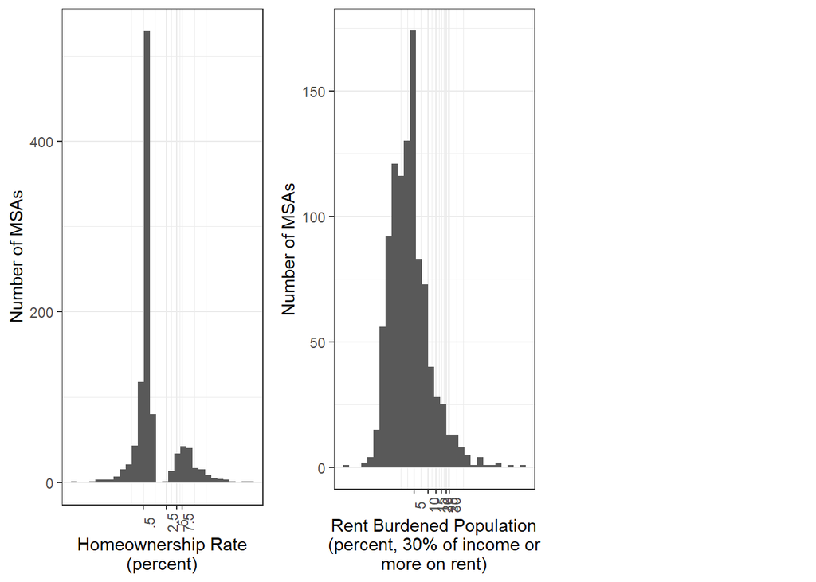

```r
pretty_pown_hist <- pown_hist +
  theme_bw() +
  scale_x_continuous(name = "Homeownership Rate\n(percent)",
                     trans = "log",
                     breaks = c(0, .5, 2.5, 5, 7.5),
                     labels = c("0", ".5", "2.5", "5", "7.5")) +
  scale_y_continuous(name = "Number of MSAs") +
  theme(axis.text.x = element_text(angle = 90))

pretty_prentburd_hist <- prentburd_hist +
  theme_bw() +
  scale_x_continuous(name = "Rent Burdened Population\n(percent, 30% of income or\nmore on rent)",
                     trans = "log",
                     breaks = c(0, 5, 10, 15, 20, 25, 30),
                     labels = c("0", "5", "10", "15", "20", "25", "30")) +
  scale_y_continuous(name = "Number of MSAs") +
  theme(axis.text.x = element_text(angle = 90))

grid.arrange(pretty_pown_hist, pretty_prentburd_hist, #pretty_houseval_hist,
             ncol = 3)
```

```r
#pretty_houseval_hist = houseval_hist +
  #theme_bw() +
  #scale_x_continuous(name = "Median Home Value\n(dollars)",
                     #breaks = seq(0, 250000, by=50000),
                     #labels = seq(0, 250000, by = 50000)) +
  #scale_y_continuous(name = "Number of MSAs") +
  #theme(axis.text.x = element_text(angle = 90))
```

##Categorical Variables We have two categorical variables: 1. Rent-burdened households by income 2. The Gini Index of Income Inequality

The rent burden variable has already been broken into 5 categories by income, however we still need to break down the Gini Index into deciles between 0 and 1.

```r
data1$GiniCat1<-cut(data1$inc_inequal, c(0,0.1,0.2,0.3,0.4,0.5,0.6, 0.7,0.8,0.9,1))
```

# Calculations

```r
#pct_Gini_index1 <- t.test(data$type == "0, 0.1")
#pct_Gini_index2 <- t.test(data$type == "0.1, 0.2")
#pct_Gini_index3 <- t.test(data$type == "0.2, 0.3")
#pct_Gini_index4 <- t.test(data$type == "0.3, 0.4")
#pct_Gini_index5 <- t.test(data$type == "0.4, 0.5")

#pct_rentburd1 <- t.test(data$type == "rentburd1")
#pct_rentburd2 <- t.test(data$type == "rentburd2")
#pct_rentburd3 <- t.test(data$type == "rentburd3")
#pct_rentburd4 <- t.test(data$type == "rentburd4")
#pct_rentburd5 <- t.test(data$type == "rentburd5")
```

## References

“Confronting Concentrated Poverty with a Mixed-Income Strategy.” Evidence Matters (Spring 2013). Office of Policy Development and Research at the United States Department of Housing and Urban Development. https://www.huduser.gov/portal/periodicals/em/spring13/highlight1.html#title.

Freedman Ellis, Greg, and Derek Burk (2020). ipumsr: Read ‘IPUMS’ Extract Files.R package version 0.4.5. https://CRAN.R-project.org/package=ipumsr

Levy, Diane K., Zach McDade, and Kassie Dumlao. “Effects from Living in Mixed-Income Communities for Low-Income Families: A Review of the Literature.” The Urban Institute (2010), 14. https://www.urban.org/sites/default/files/publication/27116/412292-Effects-from-Living-in-Mixed-Income-Communities-for-Low-Income-Families.PDF.

Manson, Steven, Jonathan Schroeder, David Van Riper, Tracy Kugler, and Steven Ruggles. IPUMS National Historical Geographic Information System: Version 16.0 [dataset]. Minneapolis, MN: IPUMS. 2021. http://doi.org/10.18128/D050.V16.0

Manson, Steven, Jonathan Schroeder, David Van Riper, Tracy Kugler, and Steven Ruggles. IPUMS National Historical Geographic Information System: Version 16.0 [dataset]. Minneapolis, MN: IPUMS. 2021. http://doi.org/10.18128/D050.V16.0

Pebesma, E., 2018. Simple Features for R: Standardized Support for Spatial Vector Data. The R Journal 10 (1), 439-446, https://doi.org/10.32614/RJ-2018-009

United States Census Bureau. 2010.

Walker, Kyle, and Matt Herman (2021). tidycensus: Load US Census Boundary and Attribute Data as ‘tidyverse’ and ‘sf’-Ready Data Frames. R package version 1.1. https://CRAN.R-project.org/package=tidycensus